# Data Science Capstone - Milestone Report

#### Author: Sachin Singh

#### Date: 21/12/2015

# Introduction

The purpose of this milestone report is to show the progress of the Capstone project. The Capstone project is part of Data Science Specialization offered by Coursera in close collaboration with SwiftKey, It uses HC Corpora dataset. The objective of this project is to build a predictive text model by using HC corpora database to predict the next word (on the basis of the previous words used earlier) to the user during writing. This report demonstrates the preliminary exploratory analysis of the data and the suggestions to build the prediction algorithm.

The [SwiftKey](https://d396qusza40orc.cloudfront.net/dsscapstone/dataset/Coursera-SwiftKey.zip) database has below three data files. This data comes in German, Finnish and English languages but for this project we are going to use English language dataset only .

1. en_US.blogs.txt - Contains Blog Posts
2. en_US.news.txt - Contains News articles.
3. en_US.twitter.txt - Contains Twitter tweets.

# Getting and Cleaning the Data

The Coursera-SwiftKey.zip file is unzipped to extract the English database as a corpus. This consists of three text files of twitter, blog and news. The data files are too big so in order to get faster data processing data samples from all three source files are generated.

```r
list.files("Coursera-SwiftKey/final/en_US")
```

```
## [1] "en_US.blogs.txt"   "en_US.news.txt"    "en_US.twitter.txt"
```

# Data Summary

```r
noofRows <- as.data.frame(cbind(countLines("Coursera-SwiftKey/final/en_US/en_US.blogs.txt")[1],
             countLines("Coursera-SwiftKey/final/en_US/en_US.news.txt")[1],
             countLines("Coursera-SwiftKey/final/en_US/en_US.twitter.txt")[1]))

fileSize <- as.data.frame(cbind(file.info("Coursera-Swiftkey/final/en_US/en_US.blogs.txt")$size / 1024^2[1],
             file.info("Coursera-Swiftkey/final/en_US/en_US.news.txt")$size / 1024^2[1],
             file.info("Coursera-Swiftkey/final/en_US/en_US.twitter.txt")$size / 1024^2[1]))

names(noofRows)<-c("en_US.blogs.txt","en_US.news.txt","en_US.twitter.txt")
rowsData <-cbind(Lines_Count=t(noofRows)[,1], Percent=t(noofRows)[,1]/sum(t(noofRows)[,1]), File_Size_MB=t(fileSize)[,1])
```

|  | Lines_Count | Percent | File_Size_MB |
| --- | --- | --- | --- |
| en_US.blogs.txt | 899288 | 0.2106219 | 200.4242 |
| en_US.news.txt | 1010243 | 0.2366087 | 196.2775 |
| en_US.twitter.txt | 2360148 | 0.5527694 | 159.3641 |

```r
SampleBlogs <- sample(blogs, size=round(length(blogs)*.01));
SampleNews <- sample(news, size=round(length(news)*.01));
SampleTwitter <- sample(twitter, size=round(length(twitter)*.01))

SampleLinesCount <- c(length(SampleBlogs), length(SampleNews), length(SampleTwitter))
SampleWordsCount <- c(length(unlist(sapply(SampleBlogs, FUN=ngramtf(1), USE.NAMES=FALSE))), length(unlist(sapply(SampleNews, FUN=ngramtf(1), USE.NAMES=FALSE))),
    length(unlist(sapply(SampleTwitter, FUN=ngramtf(1), USE.NAMES=FALSE))))
Terms <- c(length(BlogUM), length(NewsUM), length(TwitterUM))
SampleDatTable <- data.frame(cbind(Sample_lines_Count=SampleLinesCount, Sample_Words_Count=SampleWordsCount,Terms=Terms),
                                row.names=c("blogs", "news", "twitter"));
```

|  | Sample_lines_Count | Sample_Words_Count | Terms |
| --- | --- | --- | --- |
| blogs | 8993 | 381415 | 28382 |
| news | 773 | 26743 | 6701 |
| twitter | 23601 | 300278 | 25483 |

# Tokenization

The purpose of the tokenization is to suppress low frequency words and the meaningless characters in the corpus. Basically Tokenization is the way to break down the sentences into words and explains how sentences are formed. In Natural Language Processing (NLP) an n-gram is a contiguous sequence of n items from a given sequence of text or speech. The final corpus will show the words or n-gram with a high frequency which will be helpful for exploring the relationship between the words and building a statistical model. In this section ASCII chars are extracted, punctuation are removed, converted chars to lowercase etc.

# Exploratory Analysis

Let's see the word frequencies in N-grams. The sample datasets are tokenized into chunks (one word, two words, three words). The frequency of words drops off quickly like the top 10 words of these datasets are more common than the next 10, double the frequency.

### Unigrams

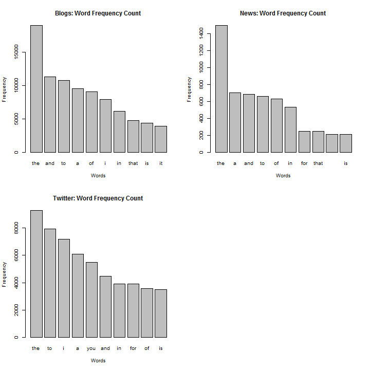

### Bigrams

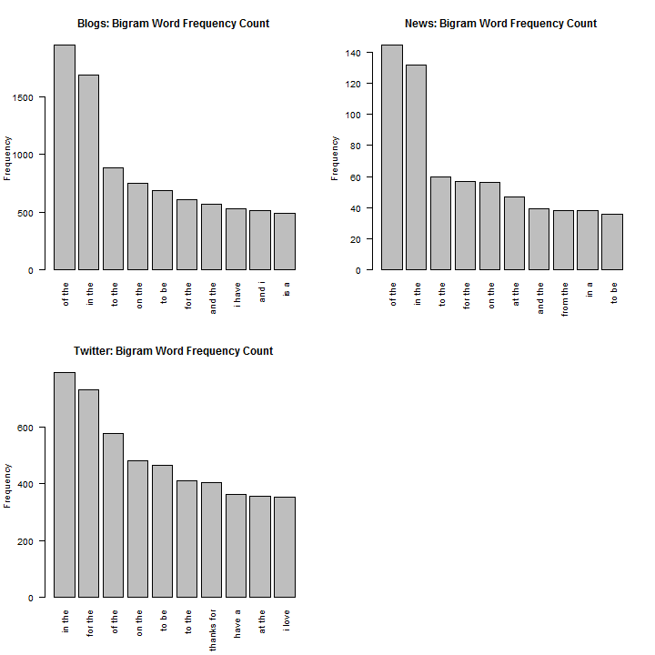

### Trigrams

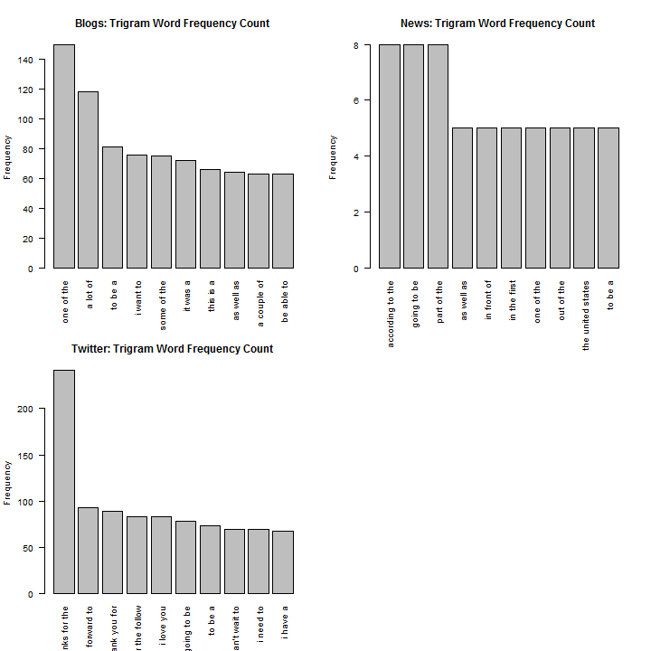

Now try looking at top 30 words (excluding stopwords) from each dataset.

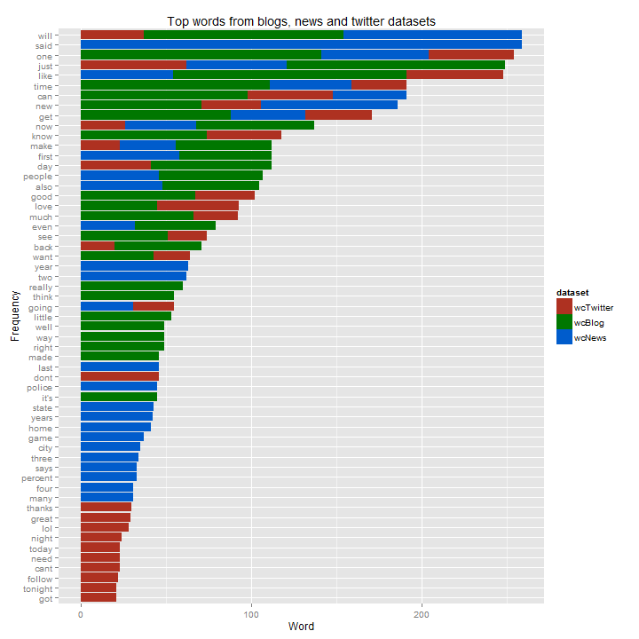

### Word Cloud Demonstration

For a better look below included word clouds for all three datasets. The size corresponds with the frequency that the word is exhibited. Using this view, we can start to see some differences between the datasets. These clouds show all words that have occurred several times in the datasets.

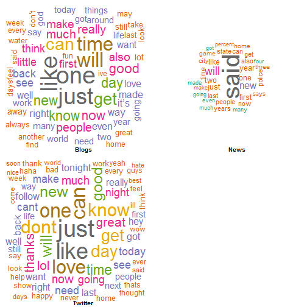

# Next Steps

- Build and evaluate a prediction model.
- Evaluate other algorithms as an alternate that can predict probability for more than one response.
- To improve the accuracy of the prediction increase the value of n for n-gram tokenization.
- Consider performance of the model, build a fast prediction algorithm.
- Develop a user friendly Shiny application to predict next word based on user input.
- Create a presentation of the application.